# 2502010976_FinalExam

Raina Imtiyaz

2022-07-16

Name : Raina Imtiyaz Student ID : 2502010976 Class : LA09 Video link : https://binusianorg-my.sharepoint.com/personal/raina_imtiyaz_binus_ac_id/_layouts/15/guestaccess.aspx?docid=057a0e588b4524483842811a2bc3da35a&authkey=AQDMwc2MkiF_mws_BcwTUho&e=bp6bcf

```r
# Used Library
library(ROCR)
```

```r
library(rpart)
library(rpart.plot)
library(ggplot2)
library(Hmisc)
library(caTools)
library(caret)
# load data
stroke_Data <- read.csv(file.choose(), header = TRUE, na.strings = c(""), stringsAsFactors = TRUE)
# choose StrokeData.csv or StrokeData.xls
```

# Exploratory Data Analysis

```r
str(stroke_Data)
```

```
## 'data.frame':    5110 obs. of  12 variables:
##  $ id               : int  9046 51676 31112 60182 1665 56669 53882 10434 27419 60491 ...
##  $ gender           : Factor w/ 3 levels "Female","Male",..: 2 1 2 1 1 2 2 1 1 1 ...
##  $ age              : num  67 61 80 49 79 81 74 69 59 78 ...
##  $ hypertension     : int  0 0 0 0 1 0 1 0 0 0 ...
##  $ heart_disease    : int  1 0 1 0 0 0 1 0 0 0 ...
##  $ ever_married     : Factor w/ 2 levels "No","Yes": 2 2 2 2 2 2 2 1 2 2 ...
##  $ work_type        : Factor w/ 5 levels "children","Govt_job",..: 4 5 4 4 5 4 4 4 4 4 ...
##  $ Residence_type   : Factor w/ 2 levels "Rural","Urban": 2 1 1 2 1 2 1 2 1 2 ...
##  $ avg_glucose_level: num  229 202 106 171 174 ...
##  $ bmi              : Factor w/ 419 levels "10.3","11.3",..: 240 419 199 218 114 164 148 102 419 116 ...
##  $ smoking_status   : Factor w/ 4 levels "formerly smoked",..: 1 2 2 3 2 1 2 2 4 4 ...
##  $ stroke           : int  1 1 1 1 1 1 1 1 1 1 ...
```

**EXPLANATION** 1. StrokeData has 5110 observations and 12 variables. 2. There are 4 integer variables (id, hypertension, heart_disease, and stroke); 6 factor variables (gender, ever_married, work_type, Residence_type, bmi, and smoking_status); 2 numeric variables (age and avg_glucose_level). 3. hypertension, heart_disease, and stroke variable only contains the numbers 1 and 0 which indicates true or false, so I will change the three variables to logical. 4. Variable “bmi” contains a number that should be numeric type, but in this data it becomes factor because there is NA string value in it, so I will change it so that there is no NA string value and the type becomes numeric.

```r
# Change hypertension, heart_disease, and stroke to logical
stroke_Data$hypertension <- as.logical(stroke_Data$hypertension)
stroke_Data$heart_disease <- as.logical(stroke_Data$heart_disease)
stroke_Data$stroke <- as.logical(stroke_Data$stroke)
```

```r
# Replace NA string value to NA
stroke_Data$bmi[stroke_Data$bmi == 'N/A'] <- NA
```

```r
# Change bmi (from factor) to numeric
stroke_Data$bmi <- as.numeric(levels(stroke_Data$bmi))[stroke_Data$bmi]
str(stroke_Data)
```

```
## 'data.frame':    5110 obs. of  12 variables:
##  $ id               : int  9046 51676 31112 60182 1665 56669 53882 10434 27419 60491 ...
##  $ gender           : Factor w/ 3 levels "Female","Male",..: 2 1 2 1 1 2 2 1 1 1 ...
##  $ age              : num  67 61 80 49 79 81 74 69 59 78 ...
##  $ hypertension     : logi  FALSE FALSE FALSE FALSE TRUE FALSE ...
##  $ heart_disease    : logi  TRUE FALSE TRUE FALSE FALSE FALSE ...
##  $ ever_married     : Factor w/ 2 levels "No","Yes": 2 2 2 2 2 2 2 1 2 2 ...
##  $ work_type        : Factor w/ 5 levels "children","Govt_job",..: 4 5 4 4 5 4 4 4 4 4 ...
##  $ Residence_type   : Factor w/ 2 levels "Rural","Urban": 2 1 1 2 1 2 1 2 1 2 ...
##  $ avg_glucose_level: num  229 202 106 171 174 ...
##  $ bmi              : num  36.6 NA 32.5 34.4 24 29 27.4 22.8 NA 24.2 ...
##  $ smoking_status   : Factor w/ 4 levels "formerly smoked",..: 1 2 2 3 2 1 2 2 4 4 ...
##  $ stroke           : logi  TRUE TRUE TRUE TRUE TRUE TRUE ...
```

**EXPLANATION** 1. hypertension, heart_disease, and stroke variables have been changed to logical, which means the number 0 has been changed to ‘FALSE’, and the number 1 has been changed to ‘TRUE’. The number of FALSE and TRUE can be seen. 2. Variable “bmi” has been changed to numeric type.

```r
summary(stroke_Data)
```

```
##        id           gender          age        hypertension    heart_disease
##  Min.   :   67   Female:2994   Min.   : 0.08   Mode :logical   Mode :logical
##  1st Qu.:17741   Male  :2115   1st Qu.:25.00   FALSE:4612      FALSE:4834
##  Median :36932   Other :   1   Median :45.00   TRUE :498       TRUE :276
##  Mean   :36518                 Mean   :43.23
##  3rd Qu.:54682                 3rd Qu.:61.00
##  Max.   :72940                 Max.   :82.00
##
##  ever_married         work_type    Residence_type avg_glucose_level
##  No :1757     children     : 687   Rural:2514     Min.   : 55.12
##  Yes:3353     Govt_job     : 657   Urban:2596     1st Qu.: 77.25
##               Never_worked :  22                  Median : 91.89
##               Private      :2925                  Mean   :106.15
##               Self-employed: 819                  3rd Qu.:114.09
##                                                   Max.   :271.74
##
##       bmi                smoking_status   stroke
##  Min.   :10.30   formerly smoked: 885   Mode :logical
##  1st Qu.:23.50   never smoked   :1892   FALSE:4861
##  Median :28.10   smokes         : 789   TRUE :249
##  Mean   :28.89   Unknown        :1544
##  3rd Qu.:33.10
##  Max.   :97.60
##  NA's   :201
```

**EXPLANATION** 1. With the summary function, we can see the details of the data. 2. Out of 5110 people, only 249 had a stroke(4.87%). 3. The average people observed are 43 years old. 4. The people observed were from 0 years old to 82 years old, and the average was 43 years old. 5. The average BMI of the people observed was 28.89, which means the average of the observed people was overwight.

*BMI chart: 18.49 and less = Underweight 18.5 - 24.99 = Normal 25 - 29.99 = Overwight 30 or greater = Obese

```r
table(stroke_Data$gender, stroke_Data$stroke)
```

```
##
##          FALSE TRUE
##   Female  2853  141
##   Male    2007  108
##   Other      1    0
```

**EXPLANATION** From the table above, it can be seen that the number of female who have had a stroke (141) is more than male (108).

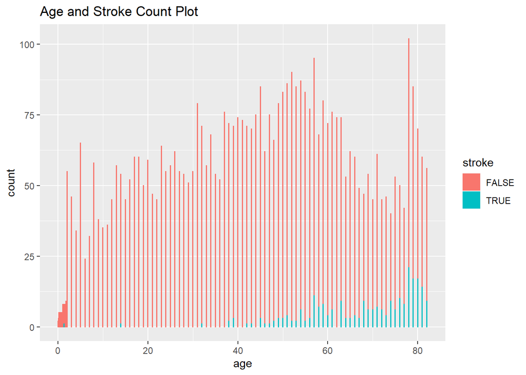

```r
ggplot(stroke_Data, aes(x = age, fill = stroke, colour = stroke)) + geom_bar(position = "stack") + ggtitle("Age and Stroke Count Plot")
```

**EXPLANATION** From the visualization above, it can be seen that more people who have had a stroke are in the age range of 60-80 years old.

```r
table(stroke_Data$hypertension, stroke_Data$stroke)
```

```
##
##         FALSE TRUE
##   FALSE  4429  183
##   TRUE    432   66
```

**EXPLANATION** From the table above, it can be seen that the number of patients who didn’t have hypertension but had a stroke (183) was more than those who had hypertension (66). It can be said that stroke doesn’t only attack people with hypertension.

```r
table(stroke_Data$heart_disease, stroke_Data$stroke)
```

```
##
##         FALSE TRUE
##   FALSE  4632  202
##   TRUE    229   47
```

**EXPLANATION** From the table above, it can be seen that the number of patients who didn’t have heart disease but had a stroke (202) was more that those who had heart disease (47). It can be said that stroke doesn’t only attack people with heart disease.

```r
table(stroke_Data$ever_married, stroke_Data$stroke)
```

```
##
##       FALSE TRUE
##   No   1728   29
##   Yes  3133  220
```

**EXPLANATION** From the table above, it can be seen that the number of married people and had a stroke (220) is more than people who are not married (29).

```r
table(stroke_Data$work_type, stroke_Data$stroke)
```

```
##
##                 FALSE TRUE
##   children        685    2
##   Govt_job        624   33
##   Never_worked     22    0
##   Private        2776  149
##   Self-employed   754   65
```

**EXPLANATION** From the table above, it can be seen that the highest number of people who have had a stroke private their work type (149). The second largest number are people who are self-employed (65). The third are people who work in the government(33). The fourth is children (2). And the last is people who never worked (0).

```r
table(stroke_Data$Residence_type, stroke_Data$stroke)
```

```
##
##         FALSE TRUE
##   Rural  2400  114
##   Urban  2461  135
```

**EXPLANATION** From the table above, it can be seen that more people who have had a stroke live in urban areas.

```r
table(stroke_Data$smoking_status, stroke_Data$stroke)
```

```
##
##                   FALSE TRUE
##   formerly smoked   815   70
##   never smoked     1802   90
##   smokes            747   42
##   Unknown          1497   47
```

**EXPLANATION** From the table above, it can be seen that more people who have had a stroke have never smoke (90). And there are 42 people who smoke and had a stroke.

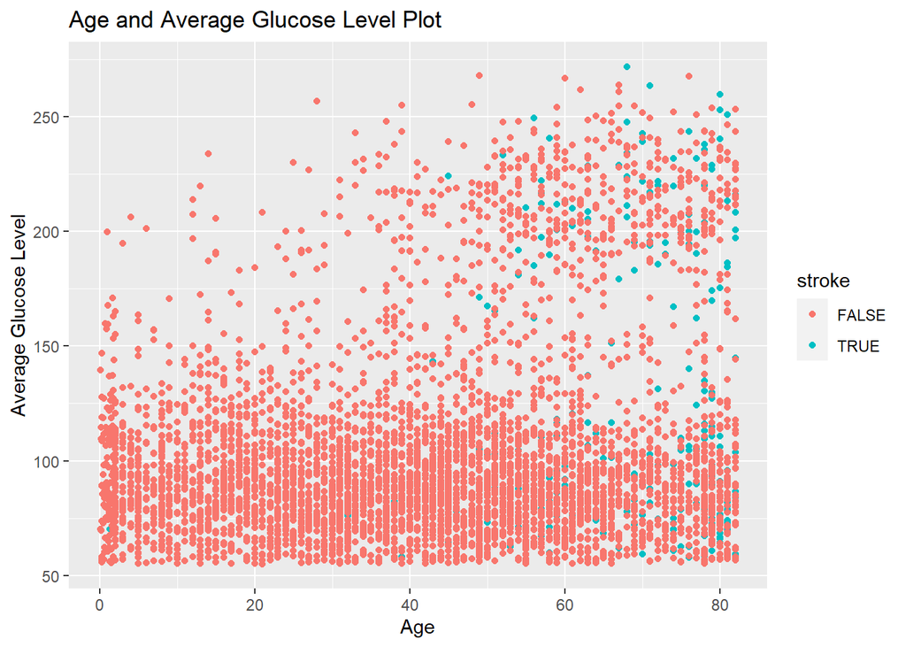

```r
ggplot(stroke_Data, aes(x = age, y = avg_glucose_level, colour = stroke)) + geom_point() + labs(title = "Age and Average Glucose Level Plot", x = "Age", y = "Average Glucose Level")
```

**EXPLANATION** From the visualization above, it can be seen that the older a person is, and the higher number of average glucose level, the higher chance of having a stroke.

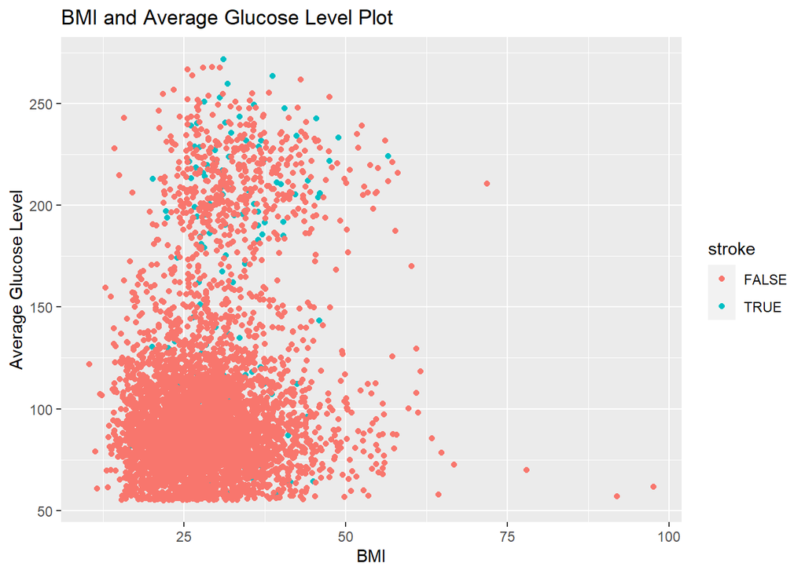

```r
ggplot(stroke_Data, aes(x = bmi, y = avg_glucose_level, colour = stroke)) + geom_point() + labs(title = "BMI and Average Glucose Level Plot", x = "BMI", y = "Average Glucose Level")
```

```r
sapply(stroke_Data, function(x) sum(is.na(x)))
```

```
##                id            gender               age      hypertension
##                 0                 0                 0                 0
##     heart_disease      ever_married         work_type    Residence_type
##                 0                 0                 0                 0
## avg_glucose_level               bmi    smoking_status            stroke
##                 0               201                 0                 0
```

**EXPLANATION** There are 201 NA values in variable “bmi”.

```r
sapply(stroke_Data, function(x) length(unique(x)))
```

```
##                id            gender               age      hypertension
##              5110                 3               104                 2
##     heart_disease      ever_married         work_type    Residence_type
##                 2                 2                 5                 2
## avg_glucose_level               bmi    smoking_status            stroke
##              3979               419                 4                 2
```

**EXPLANATION** 1. Variable “id” has 5110 unique values, because everyone’s id must be different from each other. 2. Variable “gender” has 3 unique values (female, male, and other). 3. Variable “age” has 104 unique values, means there are several people who are the same age. 4. Variable “hypertension” has 2 unique values (TRUE and FALSE). 5. Variable “heart_disease” has 2 unique values (TRUE and FALSE). 6. Variable “ever_married” has 2 unique values (Yes and No). 7. Variable “work_type” has 5 unique values (children, Govt_job, Never_worked, Private, and Self-employed). 8. Variable “Residence_type” has 2 unique values (Rural and Urban). 9. Variable “avg_glucose_level” has 3979 unique values, means there are several people who have the same average glucose level. 10. Variable “bmi” has 419 unique values, means there are several people who have the same BMI value. 11. Variable “smoking_status” has 4 unique values (formerly smoked, never smoked, smokes, and Unknown). 12. Variable “stroke” has 2 unique values (TRUE and FALSE).

# Data Preparation

```r
data <- subset(stroke_Data, select = c(2, 3, 4, 5, 6, 7, 8, 9, 10, 11, 12))
head(data)
```

```
##   gender age hypertension heart_disease ever_married     work_type
## 1   Male  67        FALSE          TRUE          Yes       Private
## 2 Female  61        FALSE         FALSE          Yes Self-employed
## 3   Male  80        FALSE          TRUE          Yes       Private
## 4 Female  49        FALSE         FALSE          Yes       Private
## 5 Female  79         TRUE         FALSE          Yes Self-employed
## 6   Male  81        FALSE         FALSE          Yes       Private
##   Residence_type avg_glucose_level  bmi  smoking_status stroke
## 1          Urban            228.69 36.6 formerly smoked   TRUE
## 2          Rural            202.21   NA    never smoked   TRUE
## 3          Rural            105.92 32.5    never smoked   TRUE
## 4          Urban            171.23 34.4          smokes   TRUE
## 5          Rural            174.12 24.0    never smoked   TRUE
## 6          Urban            186.21 29.0 formerly smoked   TRUE
```

**EXPLANATION** I didn’t put the variable “id” into the “data” subset because I don’t think that id has anything to do with stroke, id is just an identifier and differentiator for the people that being observed.

```r
dim(data)
```

```
## [1] 5110   11
```

**EXPLANATION** Variable “id” was successfully removed for the “data” subset, it can be seen that the number of variables is reduced (from 12 to 11).

```r
# Replace the NA value in bmi variable to mean value of bmi
data$bmi[is.na(stroke_Data$bmi)] <- mean(data$bmi, na.rm = TRUE)
```

**EXPLANATION** I chose to replace the NA value on bmi variable instead of removing it because 201 data is a large amount of data and will affect the accuracy of the model.

```r
head(data)
```

```
##   gender age hypertension heart_disease ever_married     work_type
## 1   Male  67        FALSE          TRUE          Yes       Private
## 2 Female  61        FALSE         FALSE          Yes Self-employed
## 3   Male  80        FALSE          TRUE          Yes       Private
## 4 Female  49        FALSE         FALSE          Yes       Private
## 5 Female  79         TRUE         FALSE          Yes Self-employed
## 6   Male  81        FALSE         FALSE          Yes       Private
##   Residence_type avg_glucose_level      bmi  smoking_status stroke
## 1          Urban            228.69 36.60000 formerly smoked   TRUE
## 2          Rural            202.21 28.89324    never smoked   TRUE
## 3          Rural            105.92 32.50000    never smoked   TRUE
## 4          Urban            171.23 34.40000          smokes   TRUE
## 5          Rural            174.12 24.00000    never smoked   TRUE
## 6          Urban            186.21 29.00000 formerly smoked   TRUE
```

**EXPLANATION** NA values in the variable “bmi” have been successfully replaced with the mean value of bmi. It can be seen in the second row of the bmi column, it’s different from the previous one. The previous one written as “NA”, and now it has been written with the mean value of bmi (28.89324).

# Split data into training (80%) and validation (20%)

```r
trData <- data[1:4088,]
valData <- data[4089:5110,]
```

```r
unique(valData$stroke)
```

```
## [1] FALSE
```

**EXPLANATION** valData stroke only has 1 unique value, so valData stroke cannot be used for logistic regression, therefore, I use sample.split() to devide the data randomly.

# Split data into training and validation using sample.split()

```r
set.seed(70)
splitData <- sample.split(data, SplitRatio = 0.8)
splitData
```

```
##  [1]  TRUE FALSE  TRUE  TRUE FALSE FALSE  TRUE  TRUE  TRUE  TRUE  TRUE
```

```r
trData2 <- subset(data, splitData == TRUE)
dim(trData2)
```

```
## [1] 3715   11
```

```r
valData2 <- subset(data, splitData == FALSE)
dim(valData2)
```

```
## [1] 1395   11
```

```r
unique(valData2$stroke)
```

```
## [1]  TRUE FALSE
```

**EXPLANATION** valData2 stroke can be used for logistic regression.

# Modelling

```r
model1 <- glm(stroke ~., family = binomial(link = "logit"), data = trData2)
summary(model1)
```

```
##
## Call:
## glm(formula = stroke ~ ., family = binomial(link = "logit"),
##     data = trData2)
##
## Deviance Residuals:
##     Min       1Q   Median       3Q      Max
## -1.1806  -0.3062  -0.1526  -0.0879   3.4580
##
## Coefficients:
##                              Estimate Std. Error z value Pr(>|z|)
## (Intercept)                -6.653e+00  8.179e-01  -8.134 4.15e-16 ***
## genderMale                  1.657e-02  1.681e-01   0.099 0.921488
## genderOther                -1.134e+01  2.400e+03  -0.005 0.996229
## age                         7.757e-02  7.066e-03  10.977  < 2e-16 ***
## hypertensionTRUE            4.399e-01  1.948e-01   2.258 0.023949 *
## heart_diseaseTRUE           3.948e-01  2.190e-01   1.803 0.071382 .
## ever_marriedYes            -1.702e-01  2.652e-01  -0.642 0.521056
## work_typeGovt_job          -1.643e+00  8.964e-01  -1.833 0.066870 .
## work_typeNever_worked      -1.172e+01  5.631e+02  -0.021 0.983397
## work_typePrivate           -1.443e+00  8.737e-01  -1.651 0.098651 .
## work_typeSelf-employed     -1.932e+00  9.020e-01  -2.142 0.032191 *
## Residence_typeUrban         1.051e-01  1.645e-01   0.639 0.522882
## avg_glucose_level           4.648e-03  1.398e-03   3.325 0.000883 ***
## bmi                         8.407e-03  1.331e-02   0.632 0.527681
## smoking_statusnever smoked -3.093e-01  2.086e-01  -1.483 0.138141
## smoking_statussmokes        2.494e-01  2.454e-01   1.016 0.309444
## smoking_statusUnknown      -1.011e-01  2.562e-01  -0.395 0.693035
## ---
## Signif. codes:  0 '***' 0.001 '**' 0.01 '*' 0.05 '.' 0.1 ' ' 1
##
## (Dispersion parameter for binomial family taken to be 1)
##
##     Null deviance: 1440.9  on 3714  degrees of freedom
## Residual deviance: 1123.0  on 3698  degrees of freedom
## AIC: 1157
##
## Number of Fisher Scoring iterations: 15
```

**EXPLANATION** From the model summary above , it can be seen that only age, hypertensionTRUE, work_typeSelf-employed, and avg_glucose_level that have stars indicating that the data are statistically significant. And there is a dot (.) on heart_diseaseTRUE, work_typeGovt_job, work_typePrivate. So I will only use data from these 4 variables for the second model.

```r
model2 <- glm(stroke ~ age + hypertension + work_type +avg_glucose_level, family = binomial(link = "logit"), data = trData2)
summary(model2)
```

```
##
## Call:
## glm(formula = stroke ~ age + hypertension + work_type + avg_glucose_level,
##     family = binomial(link = "logit"), data = trData2)
##
## Deviance Residuals:
##     Min       1Q   Median       3Q      Max
## -1.1370  -0.3127  -0.1604  -0.0883   3.4969
##
## Coefficients:
##                          Estimate Std. Error z value Pr(>|z|)
## (Intercept)             -6.569530   0.721931  -9.100  < 2e-16 ***
## age                      0.077217   0.006609  11.684  < 2e-16 ***
## hypertensionTRUE         0.434170   0.190830   2.275 0.022896 *
## work_typeGovt_job       -1.610212   0.830279  -1.939 0.052457 .
## work_typeNever_worked  -10.782677 341.823313  -0.032 0.974835
## work_typePrivate        -1.416665   0.807880  -1.754 0.079506 .
## work_typeSelf-employed  -1.896254   0.839128  -2.260 0.023834 *
## avg_glucose_level        0.005052   0.001340   3.771 0.000163 ***
## ---
## Signif. codes:  0 '***' 0.001 '**' 0.01 '*' 0.05 '.' 0.1 ' ' 1
##
## (Dispersion parameter for binomial family taken to be 1)
##
##     Null deviance: 1440.9  on 3714  degrees of freedom
## Residual deviance: 1134.5  on 3707  degrees of freedom
## AIC: 1150.5
##
## Number of Fisher Scoring iterations: 14
```

**EXPLANATION** From the model summary above, it can be seen that age and avg_glucose_level have 3 stars, while hypertensionTRUE and work_typeSelf-employed only has 1 star, so, only age and avg_glucose_level that have a high level of significance in determining stroke.

```r
model3 <- glm(stroke ~ age + avg_glucose_level, family = binomial(link = "logit"), data = trData2)
summary(model3)
```

```
##
## Call:
## glm(formula = stroke ~ age + avg_glucose_level, family = binomial(link = "logit"),
##     data = trData2)
##
## Deviance Residuals:
##     Min       1Q   Median       3Q      Max
## -0.9989  -0.3194  -0.1716  -0.0799   3.8208
##
## Coefficients:
##                    Estimate Std. Error z value Pr(>|z|)
## (Intercept)       -7.782349   0.417939 -18.621  < 2e-16 ***
## age                0.072572   0.005940  12.217  < 2e-16 ***
## avg_glucose_level  0.005514   0.001323   4.167 3.09e-05 ***
## ---
## Signif. codes:  0 '***' 0.001 '**' 0.01 '*' 0.05 '.' 0.1 ' ' 1
##
## (Dispersion parameter for binomial family taken to be 1)
##
##     Null deviance: 1440.9  on 3714  degrees of freedom
## Residual deviance: 1147.6  on 3712  degrees of freedom
## AIC: 1153.6
##
## Number of Fisher Scoring iterations: 7
```

**EXPLANATION** Model 3 only contains variables that have a hight level in determining stroke (age and avg_glucose_level).

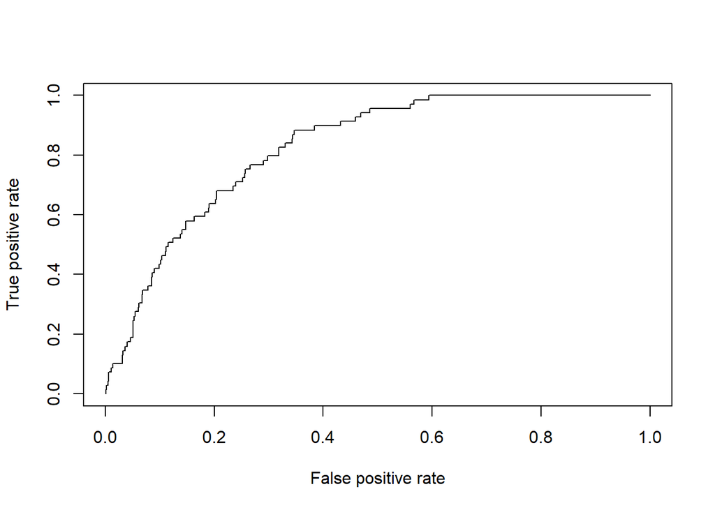

```r
predLogistic <- predict(model3, subset(valData2, select = c(2, 8)), type = "response")
strokeEval <- prediction(predLogistic, valData2$stroke)
perform <- performance(strokeEval, measure = "tpr", x.measure = "fpr")
plot(perform)
```

**EXPLANATION** Based on the visualization of the True positive rate and False positive rate plot above, it can be estimated that the AUC (Area Under the Curve) score of the model3 is in the range of 0.6 to 1.0 (based on the last increase of the y value).

```r
#Check AUC score
auc <- performance(strokeEval, measure = "auc")
auc <- auc@y.values[[1]]
auc
```

```
## [1] 0.8254858
```

AUC value Test Quality 0.9 - 1.0 Excellent 0.8 - 0.9 Very Good 0.7 - 0.8 Good 0.6 - 0.7 Satisfactory 0.5 - 0.6 Unsatisfactory

# Decision Tree Model

```r
data$stroke <- as.factor(data$stroke)
```

```r
set.seed(70)
splitData2 <- sample.split(data, SplitRatio = 0.8)
```

```r
trData3 <- subset(data, splitData2 == TRUE)
dim(trData3)
```

```
## [1] 3715   11
```

```r
unique(trData3$stroke)
```

```
## [1] TRUE  FALSE
## Levels: FALSE TRUE
```

```r
valData3 <- subset(data, splitData2 == FALSE)
dim(valData3)
```

```
## [1] 1395   11
```

# Modelling Decision Tree

```r
modelDTree <- rpart(stroke ~., data = trData3, method = "class", cp = 0.001)
modelDTree
```

```
## n= 3715
##
## node), split, n, loss, yval, (yprob)
##       * denotes terminal node
##
##   1) root 3715 180 FALSE (0.95154778 0.04845222)
##     2) age< 67.5 3102  70 FALSE (0.97743391 0.02256609)
##       4) age< 53.5 2369  21 FALSE (0.99113550 0.00886450) *
##       5) age>=53.5 733  49 FALSE (0.93315143 0.06684857)
##        10) avg_glucose_level< 191.26 610  30 FALSE (0.95081967 0.04918033)
##          20) smoking_status=never smoked,Unknown 332   8 FALSE (0.97590361 0.02409639) *
##          21) smoking_status=formerly smoked,smokes 278  22 FALSE (0.92086331 0.07913669)
##            42) heart_disease< 0.5 254  17 FALSE (0.93307087 0.06692913) *
##            43) heart_disease>=0.5 24   5 FALSE (0.79166667 0.20833333)
##              86) bmi< 33.35 17   1 FALSE (0.94117647 0.05882353) *
##              87) bmi>=33.35 7   3 TRUE (0.42857143 0.57142857) *
##        11) avg_glucose_level>=191.26 123  19 FALSE (0.84552846 0.15447154) *
##     3) age>=67.5 613 110 FALSE (0.82055465 0.17944535)
##       6) avg_glucose_level< 103.64 338  45 FALSE (0.86686391 0.13313609)
##        12) ever_married=Yes 297  34 FALSE (0.88552189 0.11447811)
##          24) avg_glucose_level>=82.835 129   7 FALSE (0.94573643 0.05426357) *
##          25) avg_glucose_level< 82.835 168  27 FALSE (0.83928571 0.16071429)
##            50) avg_glucose_level< 72.64 93  10 FALSE (0.89247312 0.10752688) *
##            51) avg_glucose_level>=72.64 75  17 FALSE (0.77333333 0.22666667)
##             102) avg_glucose_level>=73.715 68  13 FALSE (0.80882353 0.19117647) *
##             103) avg_glucose_level< 73.715 7   3 TRUE (0.42857143 0.57142857) *
##        13) ever_married=No 41  11 FALSE (0.73170732 0.26829268)
##          26) hypertension< 0.5 30   5 FALSE (0.83333333 0.16666667) *
##          27) hypertension>=0.5 11   5 TRUE (0.45454545 0.54545455) *
##       7) avg_glucose_level>=103.64 275  65 FALSE (0.76363636 0.23636364)
##        14) bmi>=29.05 134  25 FALSE (0.81343284 0.18656716)
##          28) avg_glucose_level< 241.17 127  21 FALSE (0.83464567 0.16535433)
##            56) bmi< 30.95 29   1 FALSE (0.96551724 0.03448276) *
##            57) bmi>=30.95 98  20 FALSE (0.79591837 0.20408163)
##             114) bmi>=33.8 51   7 FALSE (0.86274510 0.13725490) *
##             115) bmi< 33.8 47  13 FALSE (0.72340426 0.27659574)
##               230) age< 72.5 16   1 FALSE (0.93750000 0.06250000) *
##               231) age>=72.5 31  12 FALSE (0.61290323 0.38709677)
##                 462) bmi< 32.25 19   5 FALSE (0.73684211 0.26315789) *
##                 463) bmi>=32.25 12   5 TRUE (0.41666667 0.58333333) *
##          29) avg_glucose_level>=241.17 7   3 TRUE (0.42857143 0.57142857) *
##        15) bmi< 29.05 141  40 FALSE (0.71631206 0.28368794)
##          30) bmi< 25.75 48   9 FALSE (0.81250000 0.18750000) *
##          31) bmi>=25.75 93  31 FALSE (0.66666667 0.33333333)
##            62) smoking_status=formerly smoked,never smoked,smokes 74  21 FALSE (0.71621622 0.28378378)
##             124) avg_glucose_level< 113.705 13   1 FALSE (0.92307692 0.07692308) *
##             125) avg_glucose_level>=113.705 61  20 FALSE (0.67213115 0.32786885)
##               250) bmi>=28.65 22   4 FALSE (0.81818182 0.18181818) *
##               251) bmi< 28.65 39  16 FALSE (0.58974359 0.41025641)
##                 502) age< 78.5 27   8 FALSE (0.70370370 0.29629630) *
##                 503) age>=78.5 12   4 TRUE (0.33333333 0.66666667) *
##            63) smoking_status=Unknown 19   9 TRUE (0.47368421 0.52631579) *
```

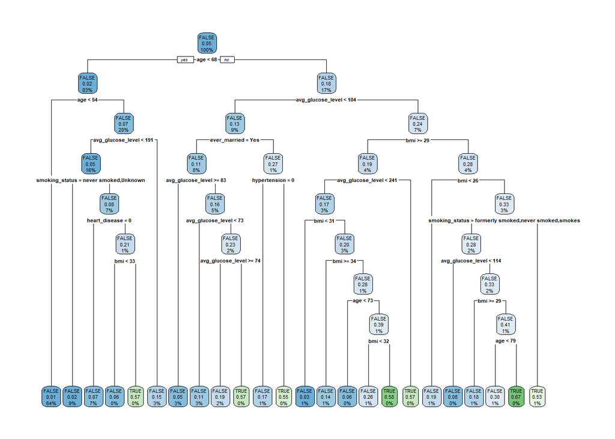

```r
rpart.plot(modelDTree)
```

# Variable Importance

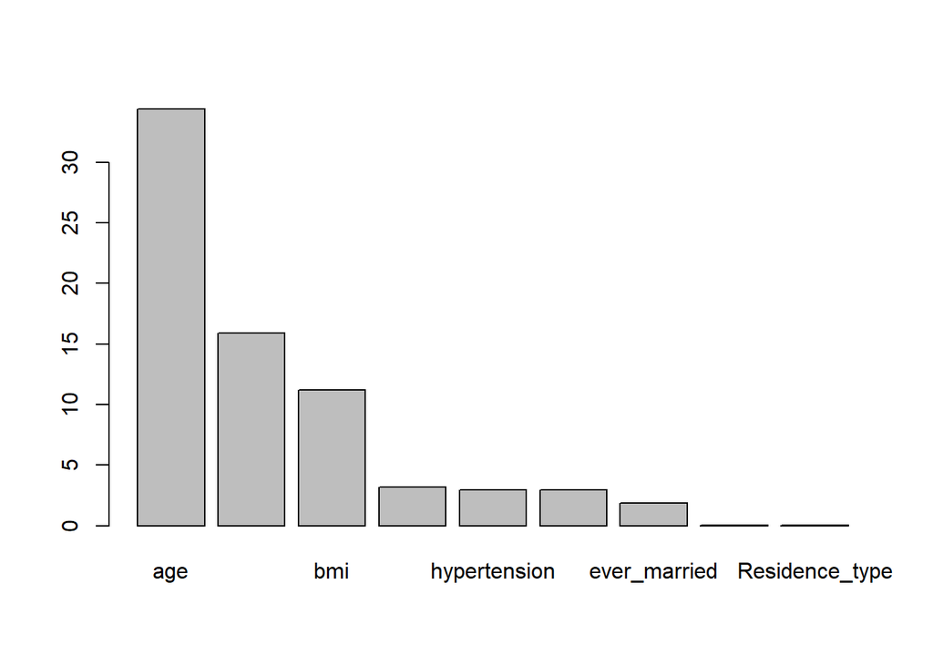

```r
imp <- modelDTree$variable.importance
barplot(imp)
```

```r
imp
```

```
##               age avg_glucose_level               bmi    smoking_status
##       34.38406650       15.91823063       11.21085843        3.17534053
##      hypertension     heart_disease      ever_married            gender
##        2.97397613        2.96615970        1.85559385        0.05216778
##    Residence_type
##        0.04836272
```

**EXPLANATION** 1. The most important variable is “age”. 2. The order is age, avg_glucose_level, bmi, smoking_status, hypertension, heart_disease, ever_married, gender, and the last is Residence_type.

```r
predDTree <- predict(modelDTree, newdata = subset(valData2, select = c(1, 2, 3, 4, 5, 6, 7, 8, 9, 10)), type = "class")
```

# Confusion Matrix

```r
cfMat <- table(predDTree, valData2$stroke)
cfMat
```

```
##
## predDTree FALSE TRUE
##     FALSE  1305   64
##     TRUE     21    5
```

**EXPLANATION** The correct prediction results are both “FALSE” or “TRUE”, which means the correct prediction for “FALSE” is 1305, and the correct prediction for “TRUE” is 5.

# Evaluation

```r
sum(diag(cfMat))
```

```
## [1] 1310
```

```r
1-sum(diag(cfMat))
```

```
## [1] -1309
```

```r
accrcy <- diag(cfMat)/rowSums(cfMat)*100
accrcy
```

```
##    FALSE     TRUE
## 95.32505 19.23077
```

**EXPLANATION** 1. Accuracy for label “FALSE” in valData2 is 95.32505. 2. Accuracy for label “TRUE” in valData2 is 19.23077.

```r
allAccrcy <- sum(diag(cfMat))/sum(cfMat)*100
allAccrcy
```

```
## [1] 93.90681
```

**EXPLANATION** The overall accuracy in valData2 is 93.90681.

# Conclusion

On the visualization of the variable importance, the variable “age” and “avg_glucose_level” are at the top rank (the first rank is age, and the second rank is avg_glucose_level).